## **SEQL3**

A análise da ação SEQL3 revela um desempenho surpreendente na última sexta-feira, dia 12 de setembro de 2025. Embalada por uma abertura mais baixa do que o fechamento do dia anterior, a cotação do ativo terminou o dia empatando com o valor de R$ 1,45, um percentual menor de 3,33% em relação ao dia anterior.A análise intraday da ação destaca um ponto de negociação outlier às 12:05:00, quando uma grande quantidade de ativos foi negociada representando 29,8% do total do dia. Este evento impactou negativamente na cotação do ativo, registrando uma variação de -3,764% logo após este ponto.Ao considerar o desempenho da ação ao longo do tempo, observamos que a variação mensal foi de 48%, trimestral de 54,3% e anual de -37%. A semana também não foi diferente, com uma variação de 46,5%.Embora o volume negociado tenha apresentado uma variação negativa de 47% em relação ao dia anterior, é importante notar que a tendência do ativo parece estar mais relacionada às flutuações intraday do que à estabilidade diária. Nesse sentido, o desempenho da ação SEQL3 pode ser considerado um dos mais surpreendentes do mercado ações na última sexta-feira. Veja a seguir o gráfico do intraday com o destaque do outlier: as setas amarelas destacam o momento e o volume negociado no ponto de outlier. A linha violeta demonstra a tendência do preço antes e depois do destaque.

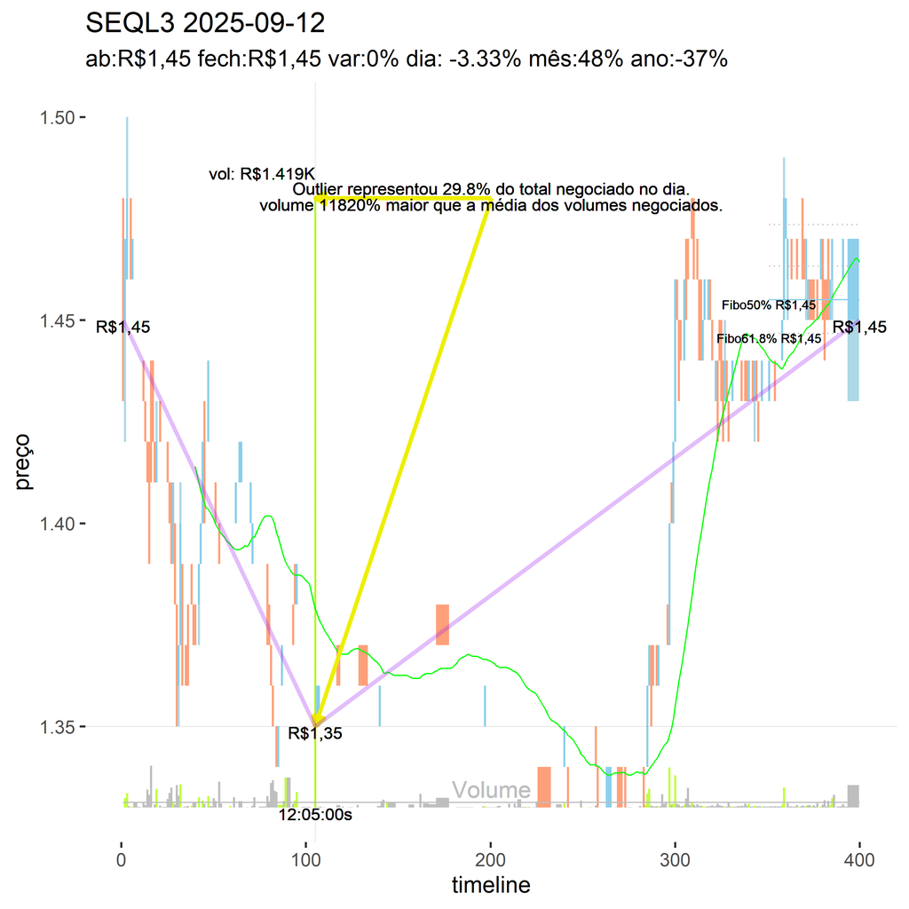

A seguir, desempenho do ativo ao longo do tempo:

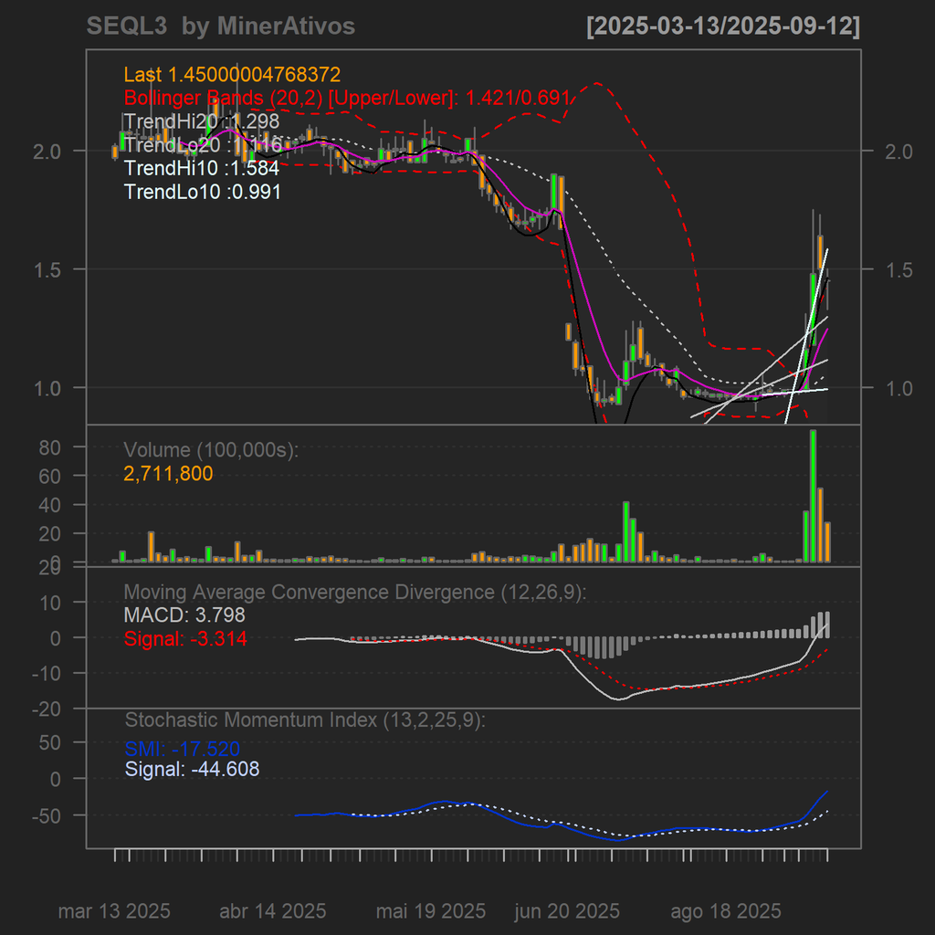

E assim concluímos nossa jornada diária pelos caminhos do mercado financeiro brasileiro. 📊💼 Espero que esses breves insights tenham contribuído e inspirado novas perspectivas sobre o fascinante universo do Ibovespa.

A conversa não termina aqui! 💬🌐 Convidamos todos vocês a compartilhar suas próprias análises, estratégias e pensamentos nos comentários. Afinal, é através do intercâmbio de ideias que todos nós prosperamos como investidores e membros desta comunidade vibrante.

Fiquem atentos para mais análises e discussões amanhã. Até lá, que seus investimentos sejam sólidos e suas decisões informadas. 🚀🔍 Juntos, vamos além dos números e construímos um entendimento mais profundo dos mercados!

#Ibovespa #AnáliseDiária #Investimentos #ComunidadeFinanceira

*Exoneração de responsabilidade*[^1]

[^1]: As informações e análises contidas neste material são de caráter meramente informativo e educacional, baseadas em dados estatísticos e análise técnica do mercado financeiro. Este material não constitui e não deve ser interpretado como uma recomendação de investimento, aconselhamento financeiro ou oferta de compra ou venda de quaisquer ativos financeiros. O autor deste material não se responsabiliza por quaisquer perdas ou danos decorrentes do uso das informações aqui apresentadas. O investimento em ações e outros ativos financeiros envolve riscos significativos, e o desempenho passado não garante resultados futuros. Cada investidor é responsável por suas próprias decisões de investimento, devendo buscar orientação de profissionais qualificados antes de tomar qualquer decisão. As análises e insights apresentados neste material refletem insights sistêmicos em um determinado momento e estão sujeitos a alterações sem aviso prévio. O autor não garante a precisão, integridade ou atualidade das informações aqui fornecidas, e não se responsabiliza por eventuais erros ou omissões. Ao utilizar este material, você concorda em isentar o autor de qualquer responsabilidade por quaisquer perdas ou danos, diretos ou indiretos, decorrentes do uso das informações aqui contidas.